# Study_scater

jmzeng1314@163.com

11 March, 2019

## 引言

教程，当然是以官网为主，不过看英文笔记有挑战，简略带领大家一起学习咯： https://bioconductor.org/packages/release/bioc/html/scater.html

值得提醒的是 2017年 11 月 这个 scater 包经过了重大变革，所以如果大家看到比较旧的教程需要注意一下，通常是无法成功的。

其GitHub的教程：http://hemberg-lab.github.io/scRNA.seq.course/

## 载入必要的R包

需要自行下载安装一些必要的R包！ 因为大量学员在中国大陆，通常不建议大家使用下面的R包安装方法，建议是切换镜像后再下载R包。参考：http://www.bio-info-trainee.com/3727.html

```r
if (!requireNamespace("Rtsne"))
    install.packages("Rtsne")
if (!requireNamespace("BiocManager"))
    install.packages("BiocManager")
if (!requireNamespace("scater"))
    BiocManager::install("scater")
if (!requireNamespace("scRNAseq"))
    BiocManager::install("scRNAseq")
if (!requireNamespace("destiny"))
    BiocManager::install("destiny")
if (!requireNamespace("SC3"))
    BiocManager::install("SC3")
```

加载R包

```r
rm(list = ls()) # clear the environment
#load all the necessary libraries
options(warn=-1) # turn off warning message globally
suppressMessages(library(scater))
suppressMessages(library(scRNAseq))
```

## 创建测试数据集

我们选择 scRNAseq 这个R包。 这个包内置的是 Pollen et al. 2014 数据集，人类单细胞细胞，分成`4`类，分别是 pluripotent stem cells 分化而成的 neural progenitor cells (“NPC”) ，还有 “GW16” and “GW21” ，“GW21+3” 这种孕期细胞。

大小是50.6 MB，下载需要一点点时间，先安装加载它们。

这个数据集很出名，截止2019年1月已经有近400的引用了，后面的人开发R包算法都会在其上面做测试，比如 SinQC 这篇文章就提到：We applied SinQC to a highly heterogeneous scRNA-seq dataset containing 301 cells (mixture of 11 different cell types) (Pollen et al., 2014).

不过本例子只使用了数据集的`4种细胞类型`而已，因为 scRNAseq 这个R包就提供了这些，完整的数据是 23730 features， 301 samples 在 https://hemberg-lab.github.io/scRNA.seq.datasets/human/tissues/

这里面的表达矩阵是由 RSEM (Li and Dewey 2011) 软件根据 hg38 RefSeq transcriptome 得到的，总是130个文库，每个细胞测了两次，测序深度不一样。

```r
library(scRNAseq)
## ----- Load Example Data -----
data(fluidigm)
# Set assay to RSEM estimated counts
assay(fluidigm)  <- assays(fluidigm)$rsem_counts
ct <- floor(assays(fluidigm)$rsem_counts)
ct[1:4,1:4]
```

```
##          SRR1275356 SRR1274090 SRR1275251 SRR1275287
## A1BG              0          0          0          0
## A1BG-AS1          0          0          0          0
## A1CF              0          0          0          0
## A2M               0          0          0         33
```

```r
table(rowSums(ct)==0)
```

```
##
## FALSE  TRUE
## 17096  9159
```

```r
# 这里使用原始表达矩阵，所以有很多基因在所有细胞均无表达量，即表现为没有被检测到，这样的基因是需要过滤掉的。

pheno_data <- as.data.frame(colData(fluidigm))
## 这里需要把Pollen的表达矩阵做成我们的 scater 要求的对象
#data("sc_example_counts")
#data("sc_example_cell_info")
# 你也可以尝试该R包自带的数据集。
# 参考 https://bioconductor.org/packages/release/bioc/vignettes/scater/inst/doc/vignette-intro.R
sce <- SingleCellExperiment(
    assays = list(counts = ct),
    colData = pheno_data
    )
sce
```

```
## class: SingleCellExperiment
## dim: 26255 130
## metadata(0):
## assays(1): counts
## rownames(26255): A1BG A1BG-AS1 ... ZZEF1 ZZZ3
## rowData names(0):
## colnames(130): SRR1275356 SRR1274090 ... SRR1275366 SRR1275261
## colData names(28): NREADS NALIGNED ... Cluster1 Cluster2
## reducedDimNames(0):
## spikeNames(0):
```

```r
# 后面所有的分析都是基于 sce 这个变量
# 是一个 SingleCellExperiment 对象，被很多单细胞R包采用。
```

## 一些质量控制

这个也非常复杂，推荐看原文说明书： https://www.bioconductor.org/packages/devel/bioc/vignettes/scater/inst/doc/vignette-qc.html

这里稍作讲解，包括基因层面及细胞层面，但是并不设计实验本身引入的干扰因素。

### 首先看基因层面的过滤

使用 calculateQCMetrics 函数作用于 sce 那个单细胞数据对象后，就可以 用 `rowData(object)` 可以查看各个基因统计指标：

- `mean_counts`: 平均表达量
- `log10_mean_counts`: 归一化 log10-scale.
- `pct_dropout_by_counts`: 该基因丢失率。
- `n_cells_by_counts`: 多少个细胞表达了该基因

上面那些指标可以用来过滤，也可以自己重新再次计算一下那些统计学指标。

主要是过滤低表达量基因，还有 `线粒体基因` 和 `ERCC spike-ins` 的控制。

```r
exprs(sce) <- log2(
    calculateCPM(sce ) + 1)
## 只有运行了下面的函数后才有各式各样的过滤指标
genes <- rownames(rowData(sce))
genes[grepl('^MT-',genes)]
```

```
## character(0)
```

```r
genes[grepl('^ERCC-',genes)]
```

```
## character(0)
```

```r
# 比较不幸的是，这个测试数据里面既没有线粒体基因，有没有ERCC序列。
sce <- calculateQCMetrics(sce,
        feature_controls = list(ERCC = grep('^ERCC',genes)))
# 也没有定义啥细胞是属于control组，所以这里并不需要完全follow教程
# example_sce <- calculateQCMetrics(example_sce,
#     feature_controls = list(ERCC = 1:20, mito = 500:1000),
#     cell_controls = list(empty = 1:5, damaged = 31:40))
```

查看信息

```r
tmp <- as.data.frame(rowData(sce))
colnames(tmp)
```

```
## [1] "is_feature_control"      "is_feature_control_ERCC"
## [3] "mean_counts"             "log10_mean_counts"
## [5] "n_cells_by_counts"       "pct_dropout_by_counts"
## [7] "total_counts"            "log10_total_counts"
```

```r
head(tmp)
```

```
##          is_feature_control is_feature_control_ERCC  mean_counts
## A1BG                  FALSE                   FALSE 1.553846e+00
## A1BG-AS1              FALSE                   FALSE 1.015385e+00
## A1CF                  FALSE                   FALSE 7.692308e-03
## A2M                   FALSE                   FALSE 1.505154e+02
## A2M-AS1               FALSE                   FALSE 1.407692e+00
## A2ML1                 FALSE                   FALSE 1.538462e-01
##          log10_mean_counts n_cells_by_counts pct_dropout_by_counts
## A1BG           0.407194731                10              92.30769
## A1BG-AS1       0.304357939                 2              98.46154
## A1CF           0.003327943                 1              99.23077
## A2M            2.180456733                21              83.84615
## A2M-AS1        0.381600985                 3              97.69231
## A2ML1          0.062147907                 9              93.07692
##          total_counts log10_total_counts
## A1BG              202           2.307496
## A1BG-AS1          132           2.123852
## A1CF                1           0.301030
## A2M             19567           4.291546
## A2M-AS1           183           2.264818
## A2ML1              20           1.322219
```

目前只过滤那些在所有细胞都没有表达的基因, 但是这个过滤条件可以自行调整。可以看到基因数量大幅度减少。

```r
keep_feature <- rowSums(exprs(sce) > 0) > 0
table(keep_feature)
```

```
## keep_feature
## FALSE  TRUE
##  9159 17096
```

```r
sce <- sce[keep_feature,]
sce
```

```
## class: SingleCellExperiment
## dim: 17096 130
## metadata(0):
## assays(2): counts logcounts
## rownames(17096): A1BG A1BG-AS1 ... ZZEF1 ZZZ3
## rowData names(8): is_feature_control is_feature_control_ERCC ...
##   total_counts log10_total_counts
## colnames(130): SRR1275356 SRR1274090 ... SRR1275366 SRR1275261
## colData names(64): NREADS NALIGNED ...
##   pct_counts_in_top_200_features_ERCC
##   pct_counts_in_top_500_features_ERCC
## reducedDimNames(0):
## spikeNames(0):
```

### 然后看细胞层面的过滤

用 `colData(object)` 可以查看各个样本统计情况

- `total_counts`: total number of counts for the cell (aka ‘library size’)
- `log10_total_counts`: total_counts on the log10-scale
- `total_features`: the number of features for the cell that have expression above the detection limit (default detection limit is zero)

等等

每个数据集都有适合自己的过滤阈值，不要局限于教程

```r
tmp <- as.data.frame(colData(sce))
colnames(tmp)
```

```
##  [1] "NREADS"
##  [2] "NALIGNED"
##  [3] "RALIGN"
##  [4] "TOTAL_DUP"
##  [5] "PRIMER"
##  [6] "INSERT_SZ"
##  [7] "INSERT_SZ_STD"
##  [8] "COMPLEXITY"
##  [9] "NDUPR"
## [10] "PCT_RIBOSOMAL_BASES"
## [11] "PCT_CODING_BASES"
## [12] "PCT_UTR_BASES"
## [13] "PCT_INTRONIC_BASES"
## [14] "PCT_INTERGENIC_BASES"
## [15] "PCT_MRNA_BASES"
```

[output cut: 49 more lines]

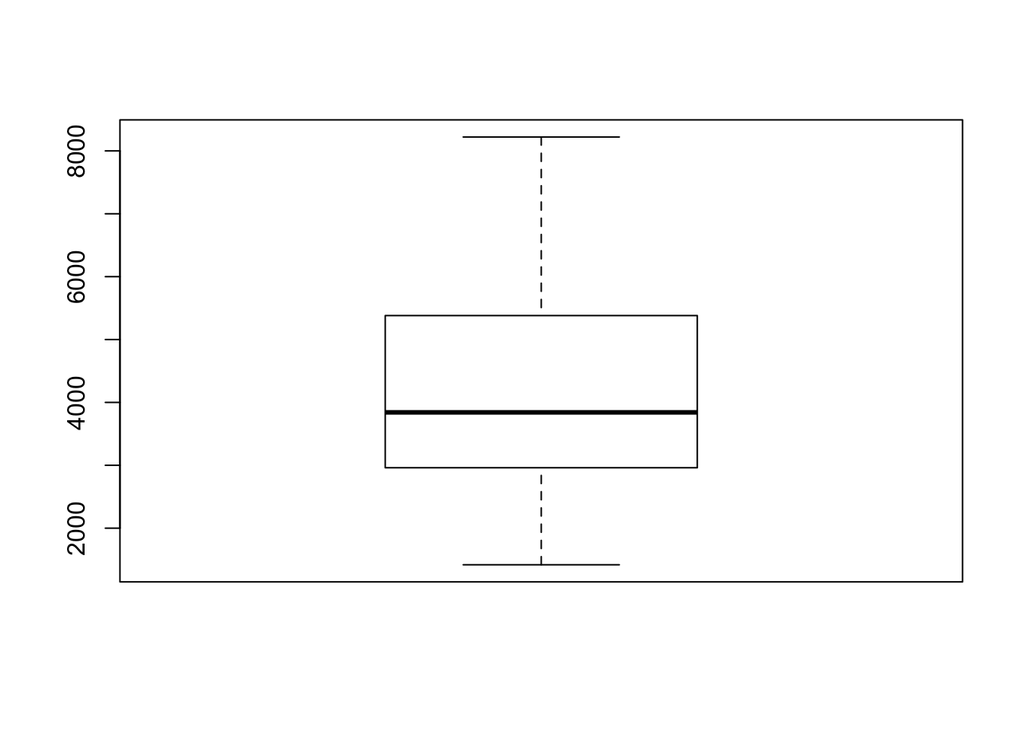

```r
# 可以发现细胞质控属性非常多，可以说是实用至极。
## 比如看每个样本测到的基因数量
tf <- sce$total_features_by_counts
boxplot(tf)
```

```r
fivenum(tf)
```

```
## [1] 1418.0 2961.0 3841.5 5381.0 8221.0
```

还有很多其它指标，比如哪些细胞的ERCC含量过高，或者某些其高表达量基因占比太高，等等。

## 一些可视化

可视化函数非常多，所以这个R包才会被引用那么广泛，里面包括如下：

首先是一些细胞距离情况

- `plotPCA`: produce a principal components plot for the cells.
- `plotTSNE`: produce a t-distributed stochastic neighbour embedding (reduced dimension) plot for the cells.
- `plotDiffusionMap`: produce a diffusion map (reduced dimension) plot for the cells.
- `plotMDS`: produce a multi-dimensional scaling plot for the cells.
- `plotReducedDim`: plot a reduced-dimension representation of the cells.

然后是一些表达量相关的:

- `plotExpression`: plot expression levels for a defined set of features.
- `plotPlatePosition`: plot cells in their position on a plate, coloured by cell metadata and QC metrics or feature expression level.
- `plotColData`: plot cell metadata and QC metrics.
- `plotRowData`: plot feature metadata and QC metrics.

### 首先可视化表达量

可以添加一些细胞属性，展示如下：

```r
# 挑选一些细胞属性（临床信息） 来进行可视化展示。
colnames(tmp)[25:28]
```

```
## [1] "Biological_Condition" "Coverage_Type"        "Cluster1"
## [4] "Cluster2"
```

```r
# 主要展现下面这些基因
rownames(sce)[1:6]
```

```
## [1] "A1BG"     "A1BG-AS1" "A1CF"     "A2M"      "A2M-AS1"  "A2ML1"
```

展示一些基因在不同细胞分类的表达区别

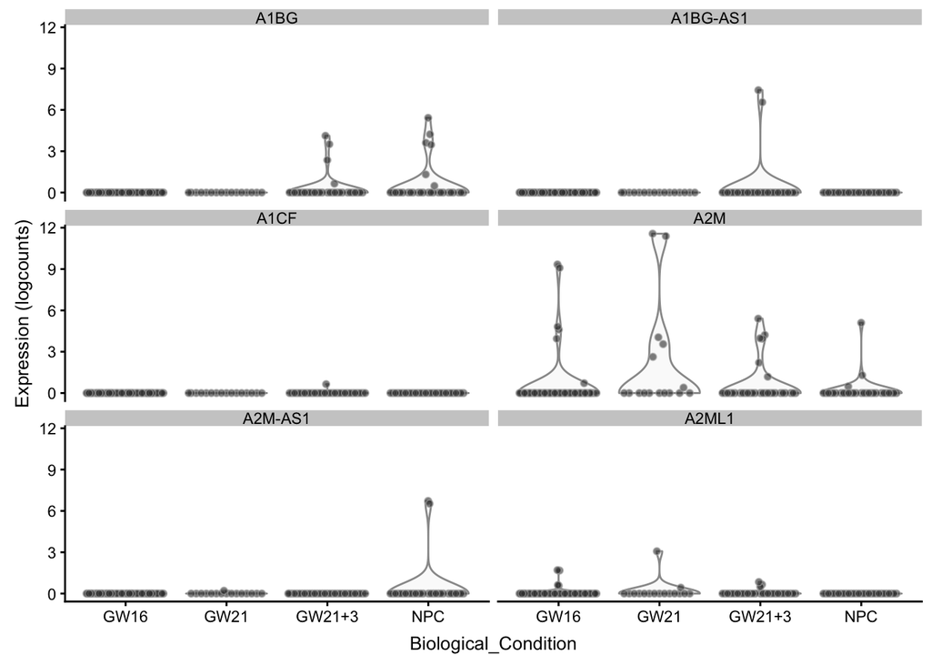

```r
## --------------------
plotExpression(sce, rownames(sce)[1:6],
               x = "Biological_Condition",
               exprs_values = "logcounts")
```

散点图，展示两个基因的相关性，这里批量展示6对相关性

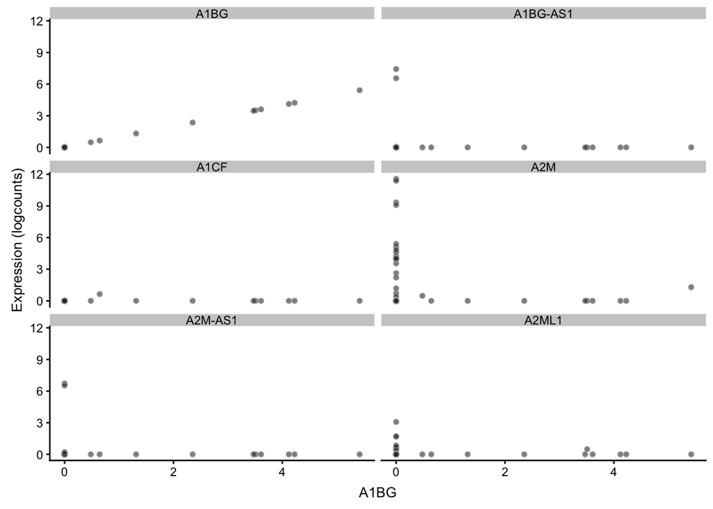

```r
## -------------------------------------------
plotExpression(sce, rownames(sce)[1:6],
               x = rownames(sce)[1])
```

还可以更复杂

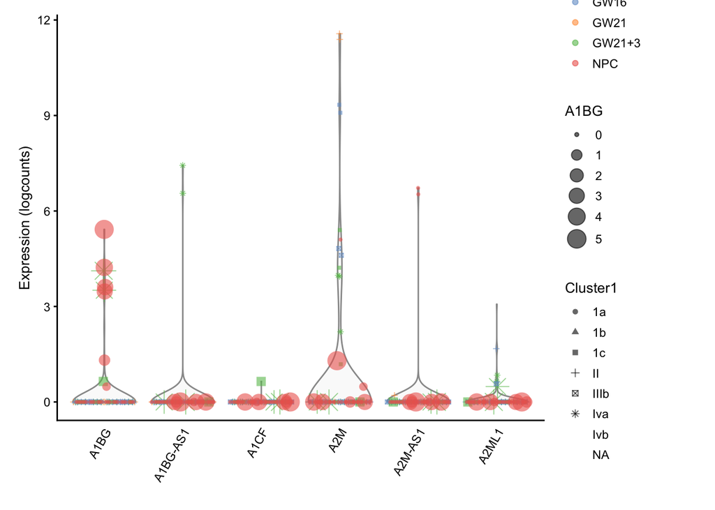

```r
## ---------------
plotExpression(sce, rownames(sce)[1:6],
               colour_by = "Biological_Condition",
               shape_by = "Cluster1",
               size_by = rownames(sce)[1])
```

### 还可以可视化细胞距离分布

这里可以学习PCA或者tSNE的使用

```r
# 举例
sce <- runPCA(sce)
# 这里并没有进行任何基因的挑选，就直接进行了PCA，与 seurat包不一样。
reducedDimNames(sce)
```

```
## [1] "PCA"
```

PCA分布图上面添加临床信息，同样的可以看到GW16混在了GW21里面

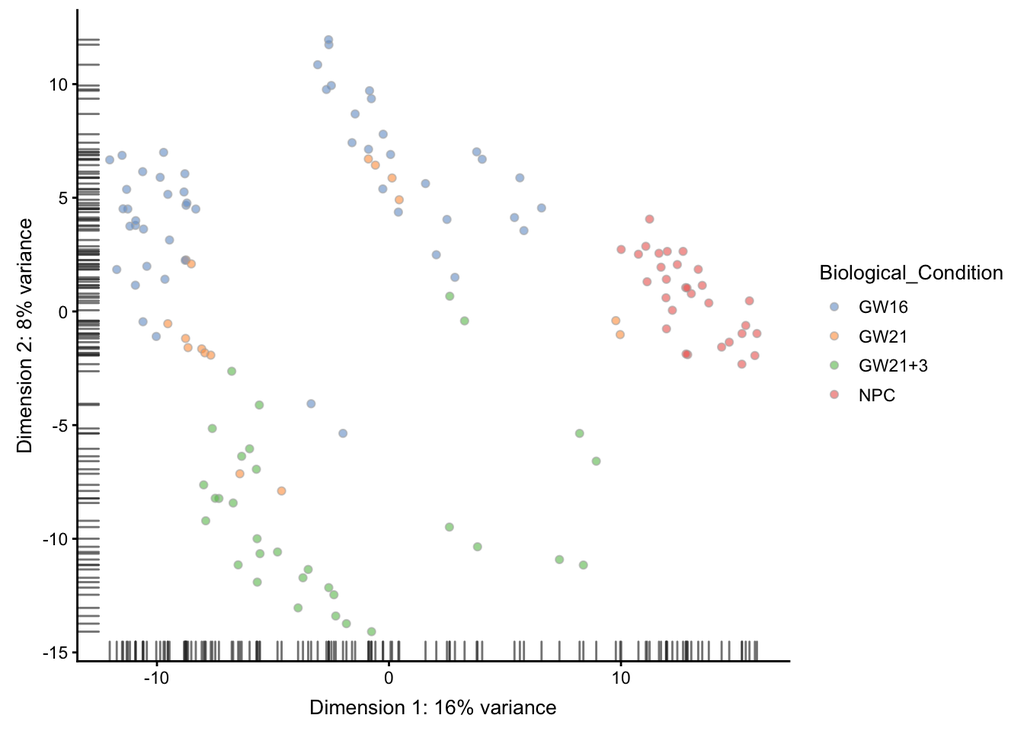

```r
## --------------
plotReducedDim(sce, use_dimred = "PCA",
               colour_by = "Biological_Condition" )
```

PCA分布图上面添加表达量信息, 但这个基本上不怎么用

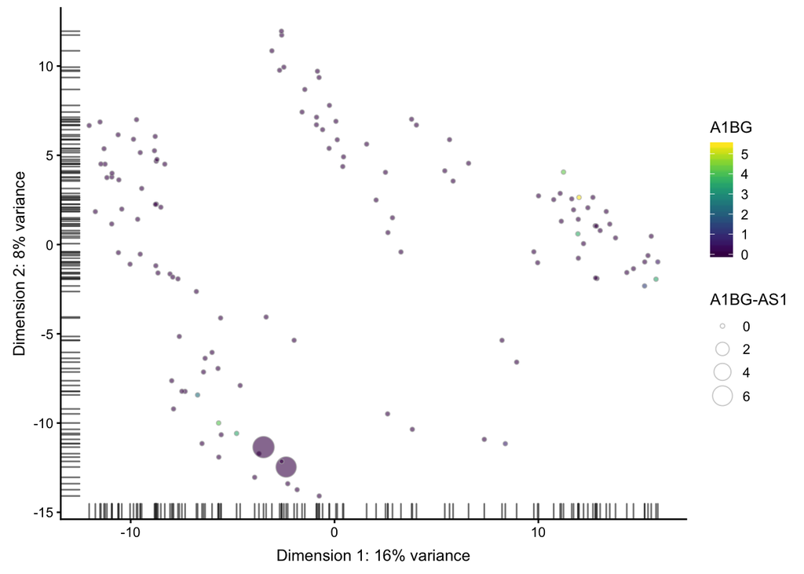

```r
## ------------
plotReducedDim(sce, use_dimred = "PCA",
               colour_by = rownames(sce)[1],
               size_by = rownames(sce)[2])
```

最原始的

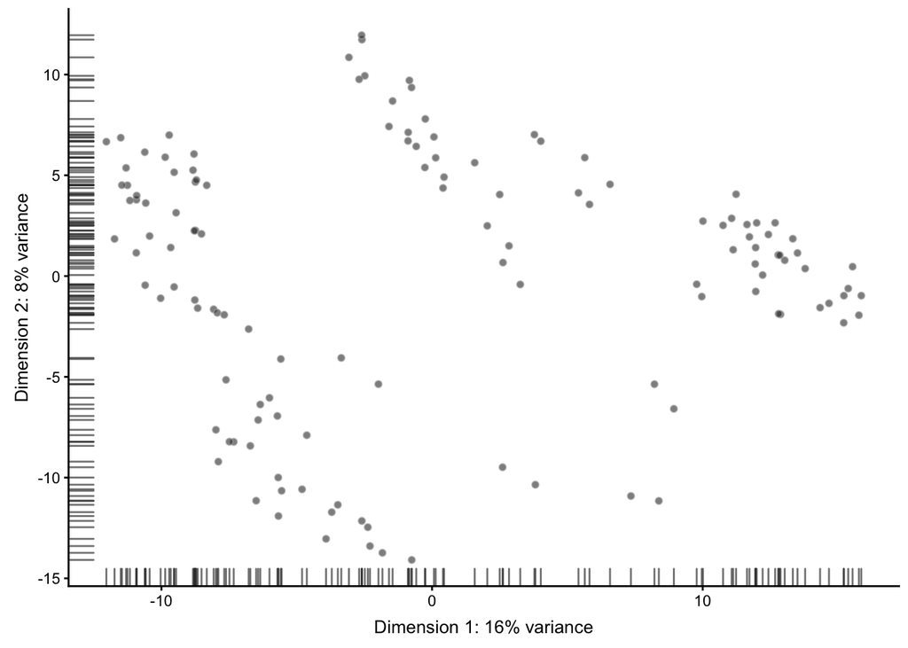

```r
## --------------
plotPCA(sce)
```

### 其它降维算法结果的可视化

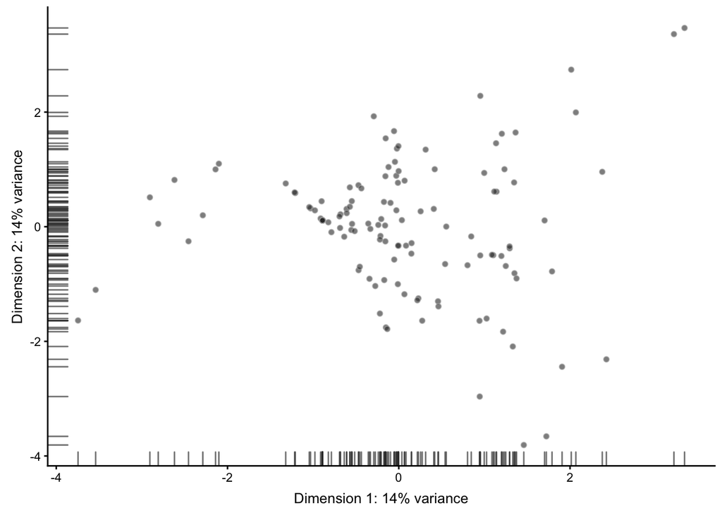

```r
## ----plot-pca-feature-controls---------------------------------------------
# 这里在真实场景中应用比较多。
sce2 <- runPCA(sce,
               feature_set = rowData(sce)$is_feature_control)
plotPCA(sce2)
```

仅仅是选取前20个PC, 可以看到绘图时候细胞分布并没有太大区别

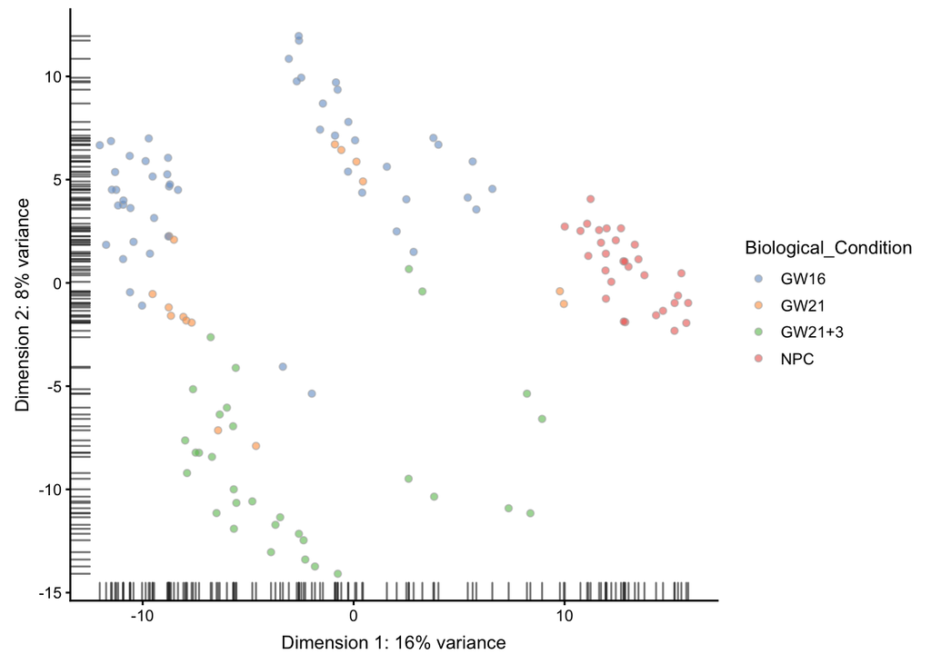

```r
## ----plot-pca-4comp-colby-shapeby------------------------------------------
sce <- runPCA(sce, ncomponents=20)
plotPCA(sce,  colour_by = "Biological_Condition" )
```

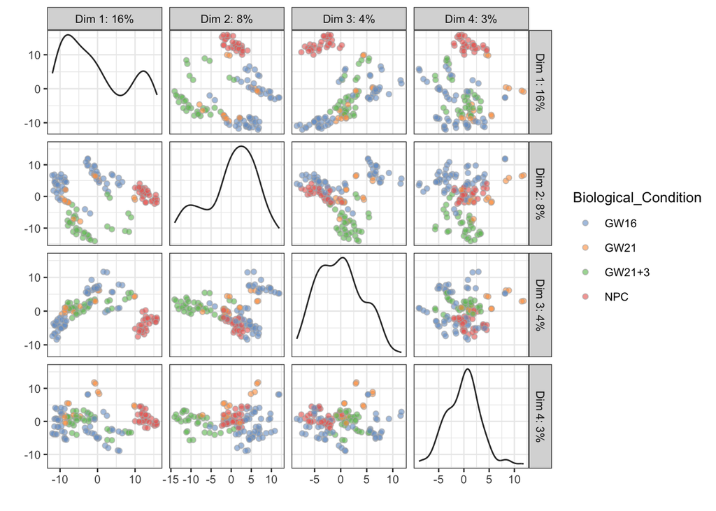

```r
plotPCA(sce, ncomponents = 4,
        colour_by = "Biological_Condition" )
```

意义不大的展示

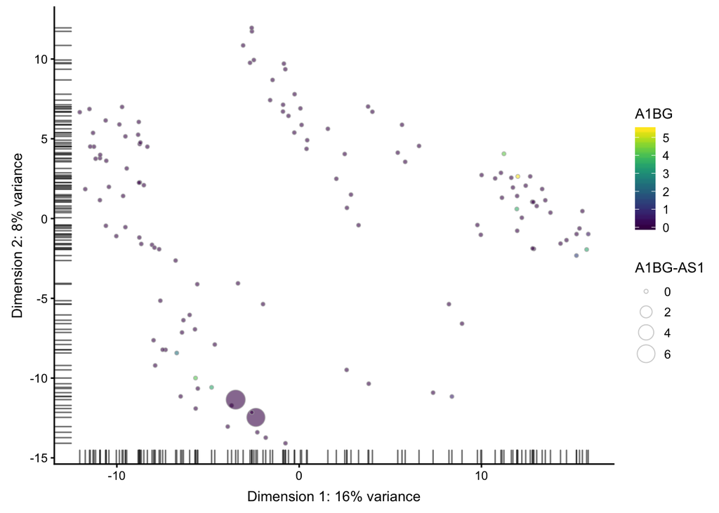

```r
## ----plot-pca-4comp-colby-sizeby-exprs-------------------------------------
plotPCA(sce,
        colour_by = rownames(sce)[1],
        size_by = rownames(sce)[2])
```

tSNE可视化

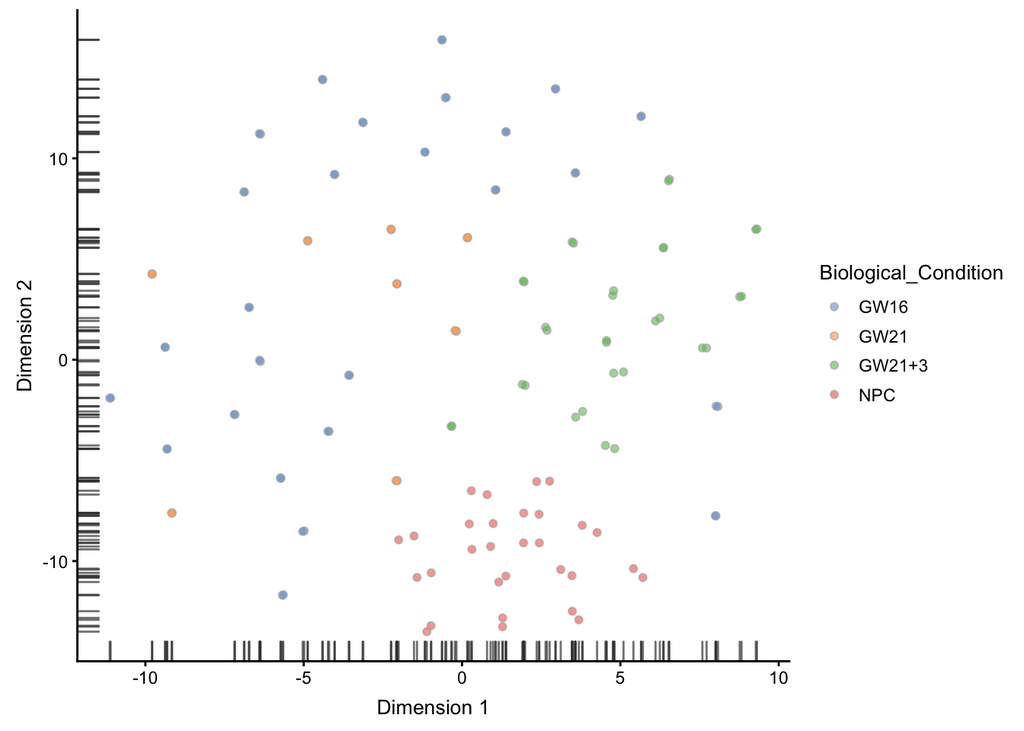

```r
## ----plot-tsne-1comp-colby-sizeby-exprs------------------------------------
# Perplexity of 10 just chosen here arbitrarily.
set.seed(1000)
# 这里的这个 perplexity 参数很重要
sce <- runTSNE(sce, perplexity=30)
plotTSNE(sce,
         colour_by = "Biological_Condition" )
```

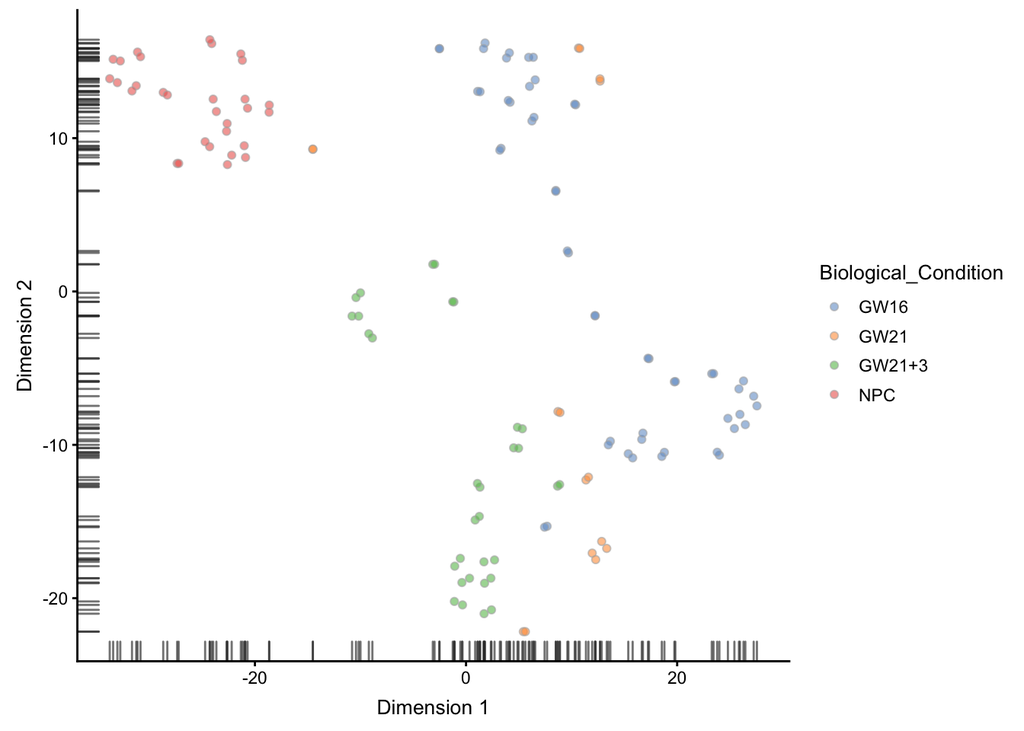

```r
## ----plot-tsne-from-pca----------------------------------------------------
set.seed(1000)
sce <- runTSNE(sce, perplexity=10, use_dimred="PCA", n_dimred=10)
plotTSNE(sce,
         colour_by = "Biological_Condition" )
```

这一步会调用destiny

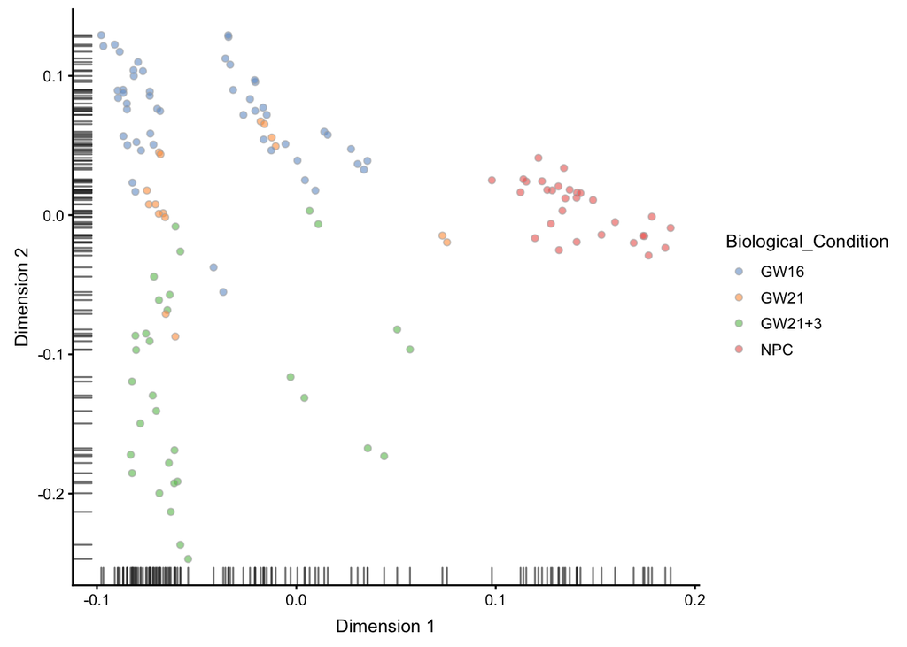

```r
## ----plot-difmap-1comp-colby-sizeby-exprs----------------------------------
sce <- runDiffusionMap(sce)
plotDiffusionMap(sce,
                 colour_by = "Biological_Condition" )
```

## 关于SC3包

虽然 SC3包 跟 scater 联系很紧密，但毕竟不属于其知识点，这里就简单运行即可。

预估亚群, 这里显示有24个, 比较多

```r
library(SC3) # BiocManager::install('SC3')
sce <- sc3_estimate_k(sce)
metadata(sce)$sc3$k_estimation
```

```
## [1] 24
```

```r
rowData(sce)$feature_symbol <- rownames(rowData(sce))
```

一步运行sc3的所有分析, 相当耗费时间

这里`kn`表示的预估聚类数, 考虑到数据集是已知的，我们强行设置为4组, 具体数据要具体考虑。

```r
# 耗费时间
kn <- 4 ## 这里可以选择 3:5 看多种分类结果。
sc3_cluster <- "sc3_4_clusters"
Sys.time()
```

```
## [1] "2019-03-11 17:44:18 CST"
```

```r
sce <- sc3(sce, ks = kn, biology = TRUE)
```

```r
Sys.time()
```

```
## [1] "2019-03-11 17:45:06 CST"
```

可视化展示部分, kn就是聚类数

热图: 比较先验分类和SC3的聚类的一致性

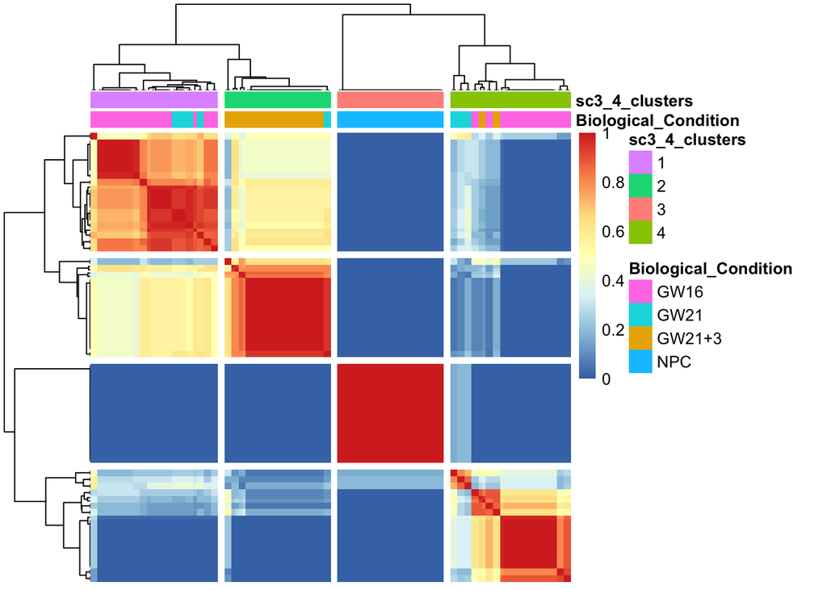

```r
sc3_plot_consensus(sce, k = kn, show_pdata = c("Biological_Condition",sc3_cluster))
```

展示表达量信息

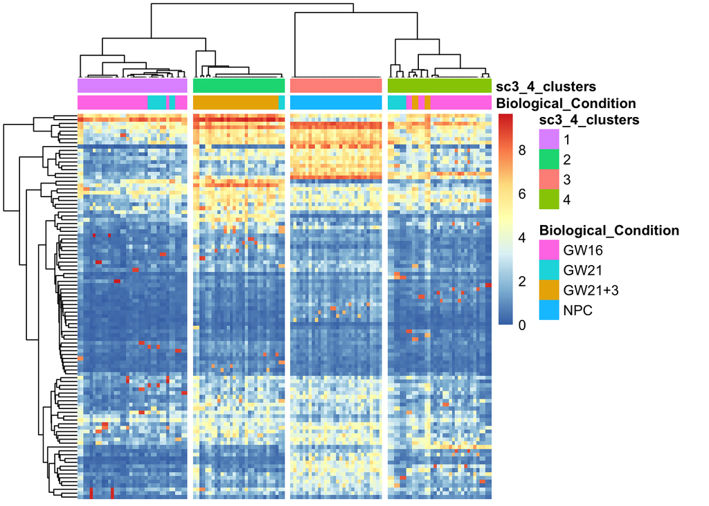

```r
sc3_plot_expression(sce, k = kn, show_pdata =  c("Biological_Condition",sc3_cluster))
```

展示可能的标记基因

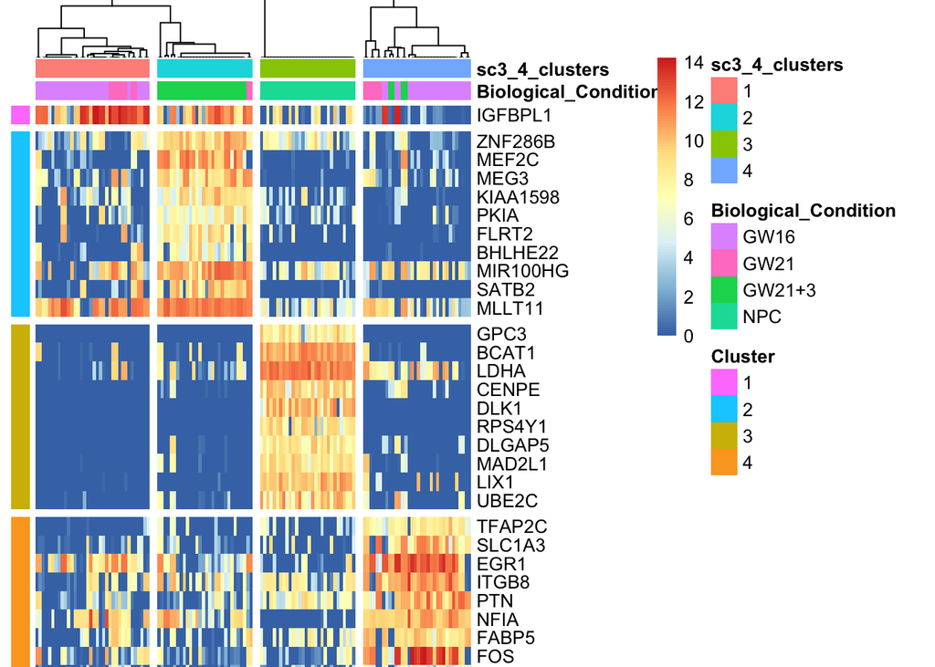

```r
sc3_plot_markers(sce, k = kn, show_pdata =  c("Biological_Condition",sc3_cluster))
```

在PCA上展示SC3的聚类结果

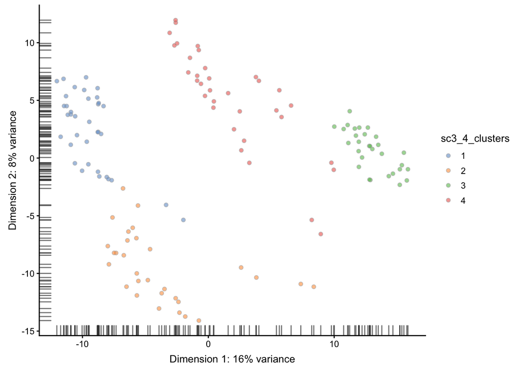

```r
plotPCA(sce, colour_by =  sc3_cluster )
```

```r
# sc3_interactive(sce)
```